Tholonia - 020-ARCHETYPES  
The Existential Mechanics of Awareness  
Duncan Stroud  
Published: January 15, 2020  
Updated: Updated: Mar 26, 2026 v8.0.89  
Welkin Wall Publishing  
ISBN-10:  
ISBN-13: 978-1-6780-2532-8  
Copyright ©2020 Duncan Stroud CC BY-NC-SA 4.0

This book is an open sourced book. This means that anyone can contribute changes or updates. Instructions and more information at https://tholonia.github.io/the-book (or contact the author at duncan.stroud@gmail.com). This book and its on-line version are distributed under the terms of the Creative Commons Attribution-Noncommercial-ShareAlike 4.0 International (CC BY-NC-SA 4.0) license, with the additional proviso that the right to publish it on paper for sale or other for-profit use is reserved to Duncan Stroud and authorized agents thereof. A reference copy of this license may be found at https://creativecommons.org/licenses/by-nc-sa/4.0/. The above terms include the following: Attribution - you must give appropriate credit, provide a link to the license, and indicate if changes were made. You may do so in any reasonable manner, but not in any way that suggests the licensor endorses you or your use. Noncommercial - You may not use the material for commercial purposes. Share Alike - If you remix, transform, or build upon the material, you must distribute your contributions under the same license as the original. No additional restrictions - you may not apply legal terms or technological measures that legally restrict others from doing anything the license permits. Notices - You do not have to comply with the license for elements of the material in the public domain or where your use is permitted by an applicable exception or limitation. No warranties are given. The license may not give you all of the permissions necessary for your intended use. For example, other rights such as publicity, privacy, or moral rights may limit how you use the material.

# 20: ARCHETYPES

###### How awareness animates language, culture, and the archetypal world

##### **Synopsis:** Having shown that awareness functions as a measurable physical force, this chapter explores how it operates in the conceptual and metaphysical domain. Language is revealed as a living map of archetypal understanding: the Names of God, the Tetragrammaton, and the concept of “I Am” are shown to encode tholonic principles directly. Archetypes are argued to be genuinely alive — sustained, strengthened, and shaped by the collective awareness directed at them through media, ritual, belief, and culture. The concept of hell as a linguistic and archetypal lineage (from Norse *Hel* to King James Bible) illustrates how unexamined archetypes infiltrate collective consciousness. Einstein and Jung are shown to have recognized non-physical intelligences as real. The chapter concludes with tulpas and golems as ancient testimony to the life of ideas, and AI swarms as their modern equivalent — thought-forms that, once energized by sufficient awareness, escape their creators’ control.

##### **Keywords:** language, metaphysics, Names of God, Tetragrammaton, I Am, living archetypes, collective awareness, media consciousness, hell, tulpa, golem, Jung, Einstein, AI swarms, ordering factors

Chapter 19 closed by asking what it is that intention keeps reinstantiating: why does the same hero appear in every culture’s mythology, the same geometry in every crystal system, the same N-D-C relationship in every sustainable structure at every scale? This chapter examines that question directly, beginning with the tool through which those patterns are most visibly transmitted and sustained: language.

## Language and Metaphysics

It is well known that language can hold a social order together or destroy it. Language has such power because the order and hierarchy of concepts that form a social order are known, taught, and defined by words. In addition, words and language form neurological pathways in our brain, and these pathways exert physiological pressure on the physical structure of the language-processing part of the brain. In his *Generative-transformational Theory* of language, the brilliant linguist Noam Chomsky states that children are born with a hard-wired understanding of language, and the only thing they need to learn is the context of how that innate understanding is culturally expressed.

Anecdotal to Chomsky’s point, my son was never taught to read or write, was raised in a house without TV, radio, or internet, and grew up in a rural environment. He was exposed to a Rudolf Steiner-esque form of learning where he was not “taught” but rather “exposed”, allowing his innate knowledge to manifest naturally. When he entered public school at the age of 8 or 9, his reading and writing abilities far exceeded those of his classmates.

It must be stated that while the first casualty of war may be truth, the first act of war is an attack on language and words, which begins long before the shooting starts. One example of such a salvo aimed at Western Culture is the post-modern concept of language and the redefining of words. This very successful neo-Marxist offensive began in the 1960s and has been so successful that by 2022, even a U.S. Supreme Court Justice was unable to define the word “woman”, and this view was staunchly supported by the largest publishing company in the U.S., which unironically reported “[her] answer was scientifically sound. There is no sufficient way to clearly define what makes someone a woman.”[^1]

Words and language are fundamental to psychology, communication, behavior, culture, cognition, relationships, perception, identity, politics, and just about every aspect of society. Consequently, describing ideas that use concepts outside our vernacular is challenging. The only solution is to define new concepts and create new words for them. Last year, 20 new words were added to the dictionary, including “ecoanxiety”, “Dunning-Kruger”, “hodophobia” (fear of traveling), “nothingburger”, and “ratio” (as in “dude, you got ratio-ed”; likes/dislikes of a social media post). The words we create and how we use words, in general, might be a good indicator of where society is headed. At least, that is the concept behind *predictive linguistics*. The problem with predictive linguistics, and words/language in general, is that each person’s different experience with words invokes a different qualitative context[^2], so even if everyone agrees on what the word “walk” means, it does not mean that word will invoke the same subjective context. The context will determine that word’s psychological, emotional, typically unconscious, or “right brain” meaning. All of us have experienced this, usually with scents, places, or things, but it also applies to words/language.

Scientific or technical words are the easiest to create because they can be clearly and definitively described. Words to convey emotions or beliefs are more challenging as they are subjective. Still, as we all have feelings and beliefs, we can all generally agree on words like “love”, “fear”, “spirit”, and “freedom”, but the specifics of these words will never be agreed upon. It’s even harder to define new words for existential or esoteric concepts, such as “awareness”, “consciousness”, “soul”, and “god”, or the metaphysical aspects of concepts like “intention”, “free will”, and “being”. The most challenging concepts to describe are those that are simultaneously technical, emotional, and metaphysical, such as energy. Energy is everything that is, can be, and will ever be. By “everything”, I mean *everything*, which includes consciousness and awareness, intentions, cause and effect, space-time, spirit, soul, free-will, and anything else you, or anyone who ever did, is or will live, can imagine.

To describe such things, we can invent new words, but unless you are a cultural icon, a world leader, or a brilliant scientist with media support, your new words will remain a mystery. Many new word creations were serendipitous and accidental, such as the word “malapropism” (nonsensical, often humorous utterance), which is an adaptation of the name of a character, *Mrs. Malaprop*, from the 1775 play “The Rivals”. Even the word “serendipity” was invented by writer and politician Horace Walpole in 1754 as an allusion to *Serendip*, an old name for Sri Lanka. “Banana republic,”catch-22,” “bedazzled,” “beatnik”, and “cyberspace” were all invented words that found a home in the collective consciousness of our culture because we could all recognize and agree on their meaning and agree that they filled a need. Creating a new word that describes a state of understanding is rare. However, this was accomplished by Robert Heinlein, who had to write an entire book (“Stranger in a Strange Land”, 1961) to define the word “grok” with nuance. Even then, the definition has been drastically reduced to a simple sentence; “*To understand intuitively or by empathy, to establish rapport with; also, to empathize or communicate sympathetically (with); also, to experience enjoyment*”.

Short of inventing new words, we can use existing words as a representative, symbolic, and metaphorical allusion to describe metaphysical, supernatural, or existential concepts. Some languages are better suited for this so that we can appropriate their words into our vernacular, such as “chi”, “chakras”, “Tao”, “gestalt”, “karma”, “mantra”, “yoga”, and “prana”.

How, then, can we talk about such broad and elusive concepts as A&I in a way that all can understand? The best we can do is use the simplest words possible, leaving less room for wildly differing interpretations. At the most fundamental level, A&I can be described as “I Am” and “I Will”. It doesn’t get more basic than that, but as we’ll see, these concepts are anything but simple.

In the thologram, we have the concept of a 0-dimensional point which only has 2 attributes, A&I. Linguistically, the singularity of that point can only be described as that which “is”, and the nothingness in which it resides is that which “is not”. This is the 1<sup>st</sup> duality of *somethingness* and *nothingness* which describes a state of existence or “being”. Applied to the subjective or 1<sup>st</sup> person context of “to be”, these would be “Not I” and “I am”, or, to borrow the opening words of the most widely known and quoted lines in modern English literature:

> “To be, or not to be” **~“Hamlet”, William Shakespeare, 1600**

We now have these 2 objective concepts: “is not” and “is”. These concepts are instances of (or lack of) Awareness, as the only prerequisite for some “thing” to exist is the awareness of its existence, as in a 0-dimensional dot. Here, a “thing” can “exist” as no more than a concept, but that concept can even be the concept of awareness! For something to exist as a concept, it does not need any other qualifier other than “to be”. It doesn’t need to “do” anything, nor does it need a purpose, reason, or rationale to exist. Thus, the only difference between “is” and “is not” is the intention “to be”.

This should sound familiar as we briefly touched on the same theme in *Chapter 10, Structure*. The association between the thologram and ancient spiritual concepts was never intended, but it was inevitable as both models are based on the same laws of existence.

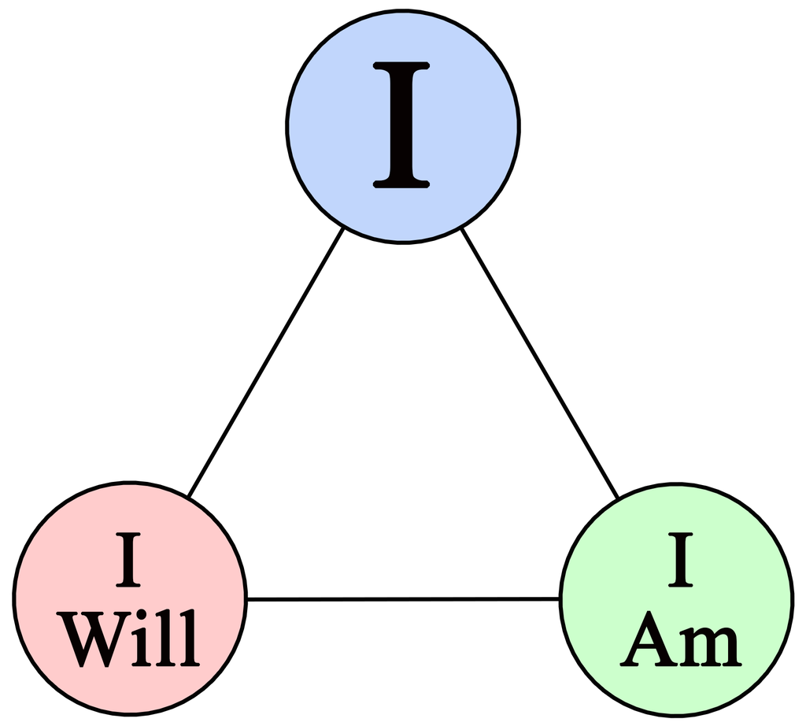

Awareness is the primal state of existence and instantiates as consciousness, which, in the 1<sup>st</sup> person human context is “I”. Intention is the primal force which created the primal movement, the 1<sup>st</sup> cause that started the chain reaction of causes and effects, instantiates as movement/energy and “I will”.

Regardless of whether these concepts have been and continue to be hotly debated over their true meaning, they are the most fundamental and straightforward concepts we have yet to conceive of. They also match our original tholonic trinity of the N-state/Negotiation/balance (“I/is”), Definition/limitation (“I am/to be”), and Contribution/integration/form (“I Will/will be”).

Language not only dictates cultural values and beliefs, but it is also inextricably linked to the formation of human consciousness[^3]<sup>,</sup>[^4]<sup>,</sup>[^5]. Hence, the limitation of languages will be reflected in the limits of consciousness (and vice versa). For example, along with our brain’s highly evolved *frontoparietal networks* ability to conceive of the concept of “I” was the conception of “Not I”. These concepts are very effective in helping the brain do what it has evolved to do, which is “*encode and integrate information acquired from the environment through sensory inputs, and then generate adaptive behavioral responses*”. The reason such concepts could even be conceived is that the most fundamental reasoning process in any brain is to distinguish between “that which is” vs. “that which is not”. A bee knows “this is (a flower)” from “this is not (a flower)”, and even ants have shown they can recognize themselves in a mirror[^6] (which is not the same as having a concept of “I”, although they clearly have a concept of “us” given that the individual ants act like neurons in a collective brain, or superorganism [^7]). This is not to say that each ant is aware of its position within this superorganism; rather, the concept of “us” exists at the archetypal level.

Even the simplest form of life that exists, the “JCVI-syn3.0”, which is the 1<sup>st</sup> designer organism in history and has only 473 genes[^8], “knows” how to differentiate between “what is” and “what is not” and does so much better than the scientists who created it. We know this because 79 genes in this organism are required for the cell to live, but no one has any idea why they are there or what they do. The organism “knows” they need to exist; otherwise, it would not have created them.

It is reasonable, then, to presume that the simplest relationship that can be recognized is between that which “is” and that which “is not”. Thus, the concept of “I/Not I” would be the 1<sup>st</sup> relationship that the *frontoparietal networks* could form once it conceived of “I”. Given that this concept has been around for about 5 million years, it must have a pretty good track record of “*generating adaptive behavioral responses*”. The “problem” with the concept of “I/Not I” is that it is based on, or rather an evolution of, the fundamental concept of existence, that of “is/not is”, which is built into all life. This makes sense as far as rules of logic go, but that does not mean it has anything to do with reality. As far as the brain is concerned, reality is whatever it can logically deduce from experience and the senses (of which only 5 get any attention, thanks to Aristotle).

A more objective view of reality tells us that it is the culmination of all that came before and the current state of an ever-changing system that has been around for 4.5 billion years. While logic may be a part of reality, just as order is a part of chaos, that does not mean that all of reality abides by the rules of whatever limited version of logic the brain has so far deduced. Consequently, that which “is not” is that which does not exist, therefore when there is no more I, “I” ceases to exist, and “I”, being purely a utilitarian construct of the *frontoparietal network* which is only interested in “*generating adaptive behavioral responses*”, can only conclude that the end of “I” is death, as “Not I” is the end of existence. While it is true that the brain’s existence comes to an end, from a tholonic view, even though the tholonic intelligence of one’s existence comes to an end at some point, that point is not necessarily at physical death. Regardless of when it comes to an end, the A&I of that intelligence can only come to an end when all of existence, in all dimensions and forms, comes to an end. Given that A&I is not a space-time phenomenon, it may exist eternally in the space-time context.

Such concepts are reinforced and passed on via language, which forms our human consciousness and understanding of reality, which is why humans tend to believe that death is the end of our existence. Metaphorically speaking, the brain (and body in general) is like an organic form of artificial intelligence whose primary objective is self-preservation, so we should expect that everything it creates is designed to support that agenda.

We can’t blame the *frontoparietal network* for doing its very impressive job, especially as it has also managed to create meta-physical concepts of relationships beyond our physical reality, much to Aristotle’s chagrin, I imagine. These meta concepts appeared shortly (~2 million years) after the *frontoparietal network* formed the concepts of “I am/I am not” and, I suspect, were closely related to and driven by our hopes and fears. Hopes and fears are probably the 2<sup>nd</sup> most vital driving force in human existence after life and death.

The concept of “I am” is not only the basis for human consciousness as we currently know it, but also for the concept of “The Creator” as we currently conceive it. In this sense, Man *was* made in the image of God, as “I am” is an instance of the archetype “To Be”.

Why are we getting into this linguistic linguine? Language is a living map of understanding, but, like all maps, it tends to hide the terrain’s reality. We can see this in the simplest concepts of “I Am” and “I Will”, which have laid the foundation of our concepts of who we are, but of God and the Universe as well. While this is not a book about religion, spirituality, or metaphysics per se, it is impossible to avoid these topics when discussing concepts as broad and encompassing as awareness, intentions, energy, and reality. Serious researchers would inevitably find themselves in territory outside their discipline, with radically different perspectives and beliefs. We can integrate these different worlds through the filter of reasoning and the humility to accept that there is far more to reality than any one perspective can describe. With this in mind, let’s look at one of the earliest and most influential concepts of existence: God.

*Note: For more on the tholonic view of the concept “I Am”, see section “I Am” in Appendix L, “The Thologram and Religion”.*

## Are Archetypes Alive?

If ideas are archetypes with energy and fields, then it would be reasonable to think that an idea could be reinforced and strengthened by adding more energy. How would one add energy to an idea? If awareness is energy, then one obvious way would be to increase an idea’s exposure to more awareness. This sort of thing is done all the time. We can see it in politics, media, culture, and traditions, even National Prayer Day in the U.S. (May 7th), when the President signs a proclamation encouraging all Americans to pray on this day and “turn to God”. Now, imagine the potential power of 114,000,000 consciousnesses all being exposed to the same symbolism at the same time, such as any of the bizarre Super Bowl half-time shows, or the 635,000,000 views of the Apollo 11 moon landing, or the London/Philadelphia Live Aid event with its 1.9 billion viewers, or the 9/11 attack on the Twin Towers which was the most-viewed television event in history, or the EU’s reality TV singing competition “Idols” that captured 3.2 billion viewers. That is half the planet’s population.

Considering that the average American youth spends 900 hours a year in school, another 1,200 hours a year watching television, that 70% of the American adult waking life is spent in front of digital media [^9] and that the average 78.6-year-old American will spend 9 years of his life watching TV, 2 years of which is just watching commercials, we’re talking about a tremendous amount of awareness, billions and billions of hours, up for grabs. How is that currently being used? Compared to the test results of the *Maharishi Effect* and its 4,000 participants, it’s hard to imagine the possibilities within reach as a global community.

Even if producers and broadcasters of media were oblivious to the power of collective awareness, which I suspect all but a few are, that much concentrated, coherent, focused awareness is naturally going to energize all sorts of “fields”, similar to how the thermal hot springs brought life to bio-goo. In the tholonic model, intelligences will outright vie for that energy, especially the less sustainable and parasitic forms, as they tend to be far more energy-greedy.

With the Internet and the decentralization of social media, we have seen a mad scramble for attention-mining and a dramatic, inevitable polarization of ideologies, beliefs, and agendas, with equally desperate, dangerous, and even deadly attempts to control that attention.

We are seeing tremendous amounts of conscious and unconscious awareness being pumped into ideas, beliefs, symbols, memes, etc., many of which have existing archetypes and, therefore, according to the tholonic model, their own awareness, intention, and intelligence.

A suspicious person might begin to suspect that some less-than-noble folks may already understand the manipulation of awareness as energy. Others may think this is bordering on the tin-foil-hat territory of mystical conspiracy theories. The reader will come to their own conclusions. We intend to question the effects of such awareness harvesting, especially in light of the understanding that ideas have a life of their own. This includes ancient ideas, even if they seem forgotten by modern society.

With that said, it must also be noted that magic and mysticism also follow as strict a set of rules and reasoning as science, if not more strict, if you consider that some magic rituals can take many months, are physically challenging to the point of being life-threatening, and leave no room for error, at least according to one of the more well-known grimoires[^10]. A significant difference between science and mysticism is that science is based on observation and relationships in the external, physical reality. In contrast, mysticism depends on observations and relationships with non-physical reality. This may sound like nonsense to some, but consider that near-death experiences (NDEs)[^11] are reported by about 17% of those who nearly die, of which only 0.1% believed the experience was not real [^12]. Out-of-body experiences are reported by 10% of the population globally [^13]. These statistically significant numbers are not easy to brush off. An even more significant statistic is that, out of the 7.87 billion people on the planet, 7.6 billion (96%) believe in some spiritual concept that, by definition, is not based on objective, physical reality.

While it is true that the laws of reality are not subject to popular opinion, political and economic pressure, and self-interest, it is definitely the case that the practice of science is. We can see an example of this in how 0.11% of the world’s population (the 8.8 million scientists[^14]) feel they have the intellectual authority to tell the other 7.87 billion people they share the planet with that they are deluded, ignorant, gullible (the official term is the “Barnum effect”[^15], i.e., “suckers”), or simply *wrong* in how they perceive their relationship with reality. Unreasonable as these presumptions may be, it is common and supported by the scientific community[^16] and research funding.

It should also be noted that many scientific breakthroughs had a mystical or paranormal element. We have seen how Newton was a dedicated alchemist and how Kekulé’s vision of an ancient mystical symbol changed organic chemistry. Einstein, though not overtly a follower of any religion, was deeply spiritual and a self-proclaimed disciple of Spinoza (1632-1677), the 17<sup>th</sup> century Jewish philosopher and mystic, and admitted his Theory of Relativity was a result of his belief that there existed an unknown and mysterious force behind the “harmony of the universe”[^17] and…

> “Behind all the discernible laws and connections, there remains something subtle, intangible, and inexplicable. Veneration for this force beyond anything that we can comprehend is my religion.” **~ Albert Einstein**

> “I assert that the cosmic religious experience is the strongest and noblest driving force behind scientific research… The religious geniuses of all ages have been distinguished by this kind of religious feeling, which knows no dogma and no God conceived in man’s image. In my view, it is the most important function of art and science to awaken this feeling and keep it alive in those who are receptive to it.” **~ Albert Einstein**

Carl Jung was not simply mystically inclined; he was a genuine mystic. As a child, Jung’s life was filled with paranormal events.[^18]

These lived experiences led Jung into psychology, and his dissertation, published in 1902, was titled “On the Psychology and Pathology of So-Called Occult Phenomena”[^19]. His ideas would open a new path to understanding the mind and consciousness.

As an adult, Jung had visions and heard voices that lasted hours, left him ill and weak, and made him think he might be schizophrenic, that is, until his visions turned out to be prophetic only months later when World War I broke out:

> I saw yellow waves, swimming rubble, and the death of thousands… two weeks passed, then the visions returned, still more violent than before, and an inner voice spoke: “Look at it, it is completely real, and it will come to pass. You cannot doubt this”. **~Carl Jung, The Red Book**

Jung was also quite clear that the paranormal exists, and science is at a loss to explain it and has little interest as well, as he states in the forward he wrote for Aniela Jaffe’s “Apparitions and precognition” [^20]:

> One of the most notable things… is the fact that among the Swiss, who are commonly regarded as stolid, unimaginative, rationalistic and materialistic, there are just as many ghost stories and such like as, say, in England or Ireland. Indeed, as I know from my own experience and that of other investigators, magic as practiced in the Middle Ages and harking back to much remoter times has by no means died out, but still nourishes today as rampantly as it did centuries ago. One doesn’t speak of these things; however, they simply happen, and the intellectuals know nothing of them, for intellectuals know neither themselves nor people as they really are. In the world of the latter, without their being conscious of it, the life of the centuries lives on, and things are continually happening that have accompanied human life from time immemorial: premonitions, foreknowledge, second sight, hauntings, ghosts, return of the dead, bewitching, sorcery, magic spells, etc. Naturally enough, our scientific age wants to know whether such things are “true”, without taking into account what the nature of any such proof would have to be and how it could be furnished. **~ Carl Jung, “Bilder und Symbole aus E.T.A. Hoffmanns Märchen ‘Der goldene Topf’”**

The arenas of science and mysticism overlap in many ways, and their differences can sometimes be purely semantic.

We accept that the Sun is our planet’s energy source and is an extraterrestrial body. Still, we don’t consider the Sun an “extraterrestrial energy being” like our ancient ancestors. However, let’s consider that there is a Sun intelligence, given that the Sun exhibits the properties of intelligence (as we defined it earlier, and certainly, the Sun is as “intelligent” as some lab-grown hydrogel. We could say the Sun is an “extraterrestrial energy intelligence” and still perfectly within the boundaries of scientific reasoning.

A science that does not explore beyond the physical is trapped in a dark cave of materialism. The tholonic view is that we can tap into these non-physical archetypal intelligences, and often do unconsciously. This is the purpose and power of myths, be they ancient or modern, as well as totems, rituals, rites, superstitions, magic, Wicca, paganism, religion, animism, etc., and with the advent of global media, we will see a renaissance of these concepts emerge in the context of our modern culture.

As these archetypes exist in the uninstantiated tholonic state, they are free from the limitations of our space-time reality. The myths and beliefs of the ancient past continue to live on in ever-evolving meanings and symbolism that sustain them, almost like a self-mutating virus that must constantly adapt to the context in which it exists.

Much of our everyday culture is inextricably bound to these archetypes. Jung described these archetypes as *ordering factors* in the collective unconscious, such as his 12 archetypes of the human psyche organized into 4 cardinal types, which we described earlier. We can find these *ordering factors* in every context of existence.

A cultural example might be how the *ordering factor* of *cooperation/conflict* instantiates as a social concept of “*Heinous deeds will be punished*”. In the context of Norse theology, this concept instantiated as the goddess named *Hel*. Her job was to judge the dead and help the apocalypse along by leading an army of the dead in a ship made of the fingernails of corpses. This is where the modern word “hell” comes from. This was also the word chosen as the literary translation (in the King James Bible) of the Hebrew word “Géenna”, which meant “valley of Hinnom”, which was where the waste of Jerusalem was dumped. This same *ordering factor* appears in cultural concepts such as karma, judgment day, guilt, original sin, and many other forms.

The concept of *hell*, or whatever it happens to be called, is deeply ingrained into the worldview and collective conscious (and unconscious) of billions of people who have little knowledge of the roots of their beliefs. Through the energy of their awareness, these believers bring into creation associated and/or parasitic archetypes that are attached to primary archetypes of which they are entirely unaware, yet which are energized by that awareness. This suggests that the more awareness directed at the specific concept of *hell*, the more energized the attached concept of an apocalypse becomes, as they are both tholonic archetypes that have a shared existence.

As a means of conveying concepts, language is a microcosm of how archetypes merge, evolve, and reproduce. An example would be how we can draw a straight line of connection from the invention of hieroglyphics and moon worship to pharmaceutical drugs and those vacuum-sealed plastic bags of imported Colombian coffee you buy at the supermarket, connecting along the way with magicians, pyramids, thieves, and secret societies.

The super-short version goes something like this: The Egyptian moon god, Thoth, who invented hieroglyphics, was adopted by the Greeks, who called him Hermes. Among other things, Hermes was the protector of thieves. He carried the Caduceus, which became the symbol of modern medicine, and was the founder of the super-secret mystical teachings of Hermetism. So protected were these teachings that the word *hermetic* became synonymous with *perfectly sealed*, hence, *hermetically sealed* bags.

[figure not shown]

What we have referred to as an uninstantiated tholon can be considered a type of *metameme*. A *meme* is defined as “*an idea, behavior, style, or usage that spreads from person to person within a culture*”. A *metameme* is “an idea or belief formed within the tholonic field (i.e. universal mind, collective unconscious, morphic field, etc.) and spreads from tholonic field to tholonic field or from archetype to archetype”. This would be a *meme* that only exists in the collective unconscious and/or in the world of archetypes.

You may have heard phrases like “*If it looks like a duck and quacks like a duck, it’s probably a duck.*”, “*When you hear hooves, think horses, not zebras.*”, or “*The simplest explanation is most likely the right one*”, otherwise known as *Occam’s Razor*. Applying the wisdom of these *abductive reasonings*, what are we to make of the fact that research out of Princeton University supports the theory that ideas, in the form of social media networks, follow the same growth models as viruses (in the form of diseases)? [^21]

Outside of the conclusion that perhaps Facebook and Twitter are some form of viral disease, it suggests that ideas follow the same patterns as natural growth, suggesting we might learn more about the life of archetypes if we considered them living. OK, viruses *may* not be “alive”, but I say *may* because some experts in the field are redefining “life” to include viruses. [^22]<sup>,</sup>[^23] Regardless, the growth, survival, and creation of ideas follow the same patterns as everything else that grows, survives, and creates. For this reason, a clever researcher might be able to find correlations between the life cycle of a galaxy and something as seemingly unrelated as, say, the life cycle of a tomato plant.

One such researcher might be Tokyo Institute of Technology’s Maruyama Shigenori, a leading geophysicist and founder of the *Center for Bio-Earth Planetology*, who, by connecting the theories of astronomy with those of the life sciences, has shown how entire planets may well be living super-organisms. Another effort comes from Department of Physics and Astronomy researchers at the University of Kansas, who theorize about the relationship between biodiversity and cosmic rays[^24].

It’s quite surprising that these new ideas are considered ground-breaking or radical in the science community considering that our own biological processes, such as sleeping, menstruating, secretion of melatonin from the pineal gland, stress levels, memory and genetic encodings [^25] are driven and controlled by cosmic conditions such as the Sun, Moon, the spinning of the earth, and even energies from the Milky Way and far off supernovas.

However, this idea that archetypes are alive raises some concerns regarding the mechanics of reality and consciousness, as we can find countless examples of how these imposed archetypes infiltrate our understanding and view of the world, such as the most powerful laser in the world, named after the Hindu god of destruction, to trivial tarot cards based on movie stars.

So, what kind of world are we creating on the planet with our awareness, desires, and beliefs? To find out, I wrote a mobile phone app that lets people send a blessing or a curse into the “ether”. The app was creatively named “Bless or Curse”.

The majority of both blessings and curses are about… wait for it… love, money, and health (surprise!). Some were touching, such as the blessing of “May he win lotto” cast upon the bus driver who “stopped just for me”. Some are bizarrely dark, such as the curse of “Torture Rape Murder die die die die die,” cast upon “Noisy Walgreen Employees”. The predominant *cursers*, were Iran, Southern Australia, Puerto Rico, Russia/North Korean border, western South Africa, and Honolulu. Predominant *blessers* were northwest Canada, southwest U.S., Eastern Europe, South Pacific, Uruguay, Ghana/Burkina Faso, Ethiopia, and the jungles of Northern Brazil.

The micro-sample of humanity seemed to be split down the middle between the *blessers* and the *cursers*, as seen in the report map below. In general, it tended to hover over the 53% area, giving the *blessers* a slight edge over the *cursers*.

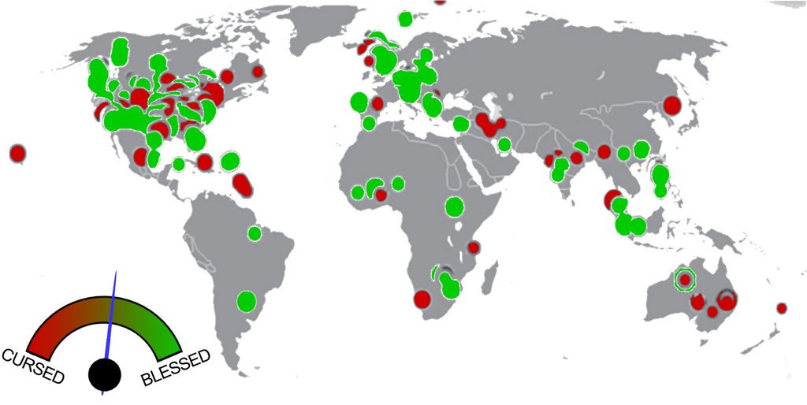

### Tulpas

One of the better legends of how ideas can take on a life of their own comes from the well-known 1932 book, *Magic And Mystery In Tibet*, by Belgian-French explorer Alexandra David-Néel.

In the Far East, there is the concept of a *tulpa*, which is a type of thought form. They are understood to be a sentient consciousness that resides in the host’s brain and can have separate feelings, thoughts, and memories from the host and communicate through thought, imagination, feelings, or verbally. With enough practice and concentration, the host can see the tulpa’s form in the real world, and for the truly advanced *tulpamancer*, it can be seen by others as well. Of course, this is a preposterous idea to Western thinkers.

Alexandra David-Neel was a woman of remarkable courage. She recounts how the only way she could enter Lhasa, Tibet’s forbidden (to foreigners) city, was to sneak in dressed as a beggar, carrying only a compass, money (for ransom in case she was kidnapped), and a gun. She was also known for her sound scientific thinking, and her opinions and observations carried weight in academic and scientific circles. Doctor A. D’Arsonval, a member of the French Academy of Sciences, the Academy of Medicine, professor at the College of France, and president of the Institute of General Psychology, said of Alexandra David-Néel:

> This well-known and courageous explorer of Tibet unites in herself all the physical, moral, and intellectual qualities that could be desired of one who is to observe and examine a subject of this kind.[^26]

So, when she described how she used the techniques taught to her by the Tibetan magicians to conjure up her own *tulpa*, it is not as easy to discard them as pure fantasy. In her case, she manifested a short, pudgy, jolly monk, as per her intentions. Perhaps even more interesting was that once it became visible to others, this tulpa began to have its own free will, a life of its own; the jolly, fat monk began to grow lean and taller and less jolly. It eventually became a major problem for her, and she had to spend 6 months “dissolving” it. As she states:

> The fat, chubby-cheeked fellow grew leaner, his face assumed a vaguely mocking, sly, malignant look. He became more troublesome and bold. In brief, he escaped my control. I ought to have let the phenomenon follow its course, but the presence of that unwanted companion began to prove trying to my nerves; it turned into a ‘day-nightmare.’ Moreover, I was beginning to plan my journey to Lhasa and needed a clear head, free of other preoccupations, so I decided to dissolve the phantom. I succeeded, but only after six months of hard struggle. My mind-creature was tenacious of life. There is nothing strange in the fact that I may have created my own hallucination. The interesting point is that in these cases of materialization, others see the thought-forms that have been created.

In Jewish folklore, there is a similar concept called a *golem* (not the *gollum* from “Lord of the Rings”, which is spelled differently). These are beings created from clay or mud and then brought to life. The most famous legend of a golem is the 16<sup>th</sup> century *Golem of Prague*. This massive golem was specifically created to help protect the oppressed Jews. Still, due to simple human error, the golem went berserk, destroyed the neighborhood, and was ultimately disabled and stored in the attic of a synagogue for hundreds of years until the Nazis bombed that synagogue in WWII. Some people believe it was not destroyed and is waiting to be returned to life.

Whether tulpas and golems exist or not is left to the reader. The point is that the belief that ideas can take on a life of their own is neither new nor unique.

Perhaps we shall see our modern versions of tulpas and golems soon, as that is where the research into what is essentially the collective consciousness of artificial intelligence, or *A.I. Swarms*, as they are called,[^27]<sup>,</sup>[^28] and early attempts to create artificial humans[^29] appears to be heading. No doubt, one day, they too will prove to be “more troublesome and bold, escaping our control.” Stanley Kubrick and Arthur C. Clarke brilliantly captured this concept of a *digital tulpa* in 1968 when the heuristically programmed algorithmic computer, the HAL-9000, in the movie “*2001: A Space Odyssey*”, calmly told its creators:

> I’m sorry, Dave. I’m afraid I can’t do that.

What this chapter has traced is a single thread running from the simplest primal expression of existence (“I Am”) through to the most complex modern technologies. Language is not merely a communication tool; it is the medium through which archetypes propagate and accumulate awareness. The tholonic “I Am / I Will” pairing is the linguistic skeleton of the N-state and the intention that drives instantiation. Collective awareness, whether directed at a Super Bowl half-time show or a National Prayer Day, is not a passive phenomenon; it is energy that archetypes actively vie for, and the less sustainable forms, being more energy-hungry, tend to be the most aggressive competitors. Einstein’s “spirit manifest in the laws of the Universe” and Jung’s ordering factors of the collective unconscious are two formulations of the same tholonic observation: that non-physical intelligences shaped by accumulated A&I are as real and as causally effective as any physical force. Tulpas, golems, and AI swarms are not folklore and science fiction; they are the practical demonstration that a sufficiently concentrated field of directed awareness can produce self-sustaining, autonomous patterns that outlast and escape the intentions of their creators.

The question this raises immediately is what governs where these patterns go once they are in motion. If the thologram provides the structural channels through which all energy flows, and if archetypes are the stable low-entropy nodes at which those channels converge, then the paths themselves must be in some sense fixed before any particular tholon begins its journey along them. That is the subject of Chapter 21.

[^1]: Dastagir, Alia E. “**Marsha Blackburn Asked Ketanji Brown Jackson to Define ”Woman”. Science Says There’s No Simple Answer.**” USA Today. Gannett Satellite Information Network, March 28, 2022. https://www.usatoday.com/story/life/health-wellness/2022/03/24/marsha-blackburn-asked-ketanji-jackson-define-woman-science/7152439001/.
[^2]: VERHAGEN, VÉRONIQUE & Mos, Maria & Backus, Ad & SCHILPEROORD, JOOST. (2018). “**Predictive language processing revealing usage-based variation.**” Language and Cognition. 10. 329-373. 10.1017/langcog.2018.4. https://www.researchgate.net/publication/325566313_Predictive_language_processing_revealing_usage-based_variation/citation/download
[^3]: Shaghaghi, Mehran, “**Language and Consciousness; How Language Implies Self-awareness**”. University of Illinois, Chicago. Mehran Shaghaghi is a physicist with a comprehensive foundation in multidisciplinary areas of bioengineering, soft-matter physics, and quantum mechanics. https://philarchive.org/archive/SHALAC-3
[^4]: Weitzman RS. A Review of “**Language: The Cultural Tool**” by Daniel L. Everett. Anal Verbal Behav. 2013;29(1):185–98. PMCID: PMC3659492. https://www.ncbi.nlm.nih.gov/pmc/articles/PMC3659492/
[^5]: Woźniak M. “**‘I’ and ‘Me’: The Self in the Context of Consciousness**”. Front Psychol. 2018 Sep 4;9:1656. doi: 10.3389/fpsyg.2018.01656. PMID: 30233474; PMCID: PMC6131638. https://www.ncbi.nlm.nih.gov/pmc/articles/PMC6131638/
[^6]: Tricot, M. and Roger Cammaerts. “**Are ants (Hymenoptera, Formicidae) capable of self-recognition?**” *Journal of science* 5 (2015): 521-532. http://www.journalofscience.net/showpdf/MjY4a2FsYWkxNDc4NTIzNjk=
[^7]: Sasaki, Takao, and Stephen C. Pratt. “**The Psychology of Superorganisms: Collective Decision Making by Insect Societies.**” *Annual Review of Entomology* 63, no. 1 (2018): 259–75. https://doi.org/10.1146/annurev-ento-020117-043249.
[^8]: Krulwich, Robert. “**We Built the World’s Simplest Cell-but Dunno How It Works.**” Science. National Geographic, May 3, 2021. https://www.nationalgeographic.com/science/article/we-built-the-worlds-simplest-cell-but-dunno-how-it-works#:~:text=But%20if%20we%20look%20for,forms%20we’ve%20ever%20seen.
[^9]: Average time Americans adults (18+) spend with electronic media Q4 2014. Source: Nielsen.
[^10]: Abraham von Worms (14th century), “**The Book of Abramelin**”, Translated by Steven Guth. Edited by George Dehn. 2001. Nicolas-Hays, Inc, First Edition (January 1, 2011). Note: There are various versions of this book. This version is considered to be a more complete and accurate translation of the original material.
[^11]: “**Current NDEs**”. https://nderf.org/Archives/NDERF_NDEs.html.
[^12]: Long, J. (2014). “**Near-Death Experiences Evidence for Their Reality”**. *Missouri Medicine*, *111*(5), 372-380. https://www.ncbi.nlm.nih.gov/pmc/articles/PMC6172100/
[^13]: Blanke, O. (2004). “**Out of body experiences and their neural basis: They are linked to multisensory and cognitive processing in the brain**”. *BMJ : British Medical Journal*, *329*(7480), 1414-1415. https://doi.org/10.1136/bmj.329.7480.1414
[^14]: Naujokaitytė, Goda. “**Number of Scientists Worldwide Reaches 8.8m, as Global Research Spending Grows Faster than the Economy.**” Science. Accessed October 22, 2022. https://sciencebusiness.net/news/number-scientists-worldwide-reaches-88m-global-research-spending-grows-faster-economy.
[^15]: “**Barnum Effect.**” Encyclopædia Britannica. Encyclopædia Britannica, Inc. Accessed October 22, 2022. https://www.britannica.com/science/Barnum-Effect.
[^16]: Linden, Sander van der. “**How Come Some People Believe in the Paranormal?**” Scientific American. Scientific American, September 1, 2015. https://www.scientificamerican.com/article/how-come-some-people-believe-in-the-paranormal/. Note: This article is embarrassingly biased, and the studies they quote are astonishingly disingenuous. One of the test questions that one study uses is a rather famous question that 50% of M.I.T, Harvard, and Yale students got wrong, and 80% of typical university students got wrong (A bat and ball cost $1.10. The bat costs one dollar more than the ball. How much does the ball cost?). The study’s authors and the SA article conflate our neurological preference for either *time-preference* or *risk-preference* decision making (See: Frederick, Shane. 2005. “**Cognitive Reflection and Decision Making.**” *Journal of Economic Perspectives*, 19 (4): 25-42.DOI: 10.1257/089533005775196732, https://www.aeaweb.org/articles?id=10.1257/089533005775196732), with the assumption that *time-preference* decision-making indicates lazy or weak thinking. Even worse, they conclude with, “Is there any way to protect people from falling prey to such magical thinking?” and then equate it with “misinformation” and “conspiracy theories”.
[^17]: Swami Tathagatananda, “**Albert Einstein - The Mystic**”, Vedanta Society of New York, published in Prabuddha Bharata, August 2008, https://lakshminarayanlenasia.com/wp-content/uploads/2020/08/Albert_Einstein_Mystic.pdf
[^18]: Lance S. Owens and Stephan A. Hoeller, “**Carl Gustav Jung and The Red Book: Liber Novus**”, *Encyclopedia of Psychology and Religion*, 2nd edition, (Springer Reference, 2014) ISBN 978-1-4614-6085-5. Online edition: https://www.academia.edu/6922901/C._G._Jung_and_the_Red_Book
[^19]: Available online https://muse.jhu.edu/book/75874
[^20]: Jaffe, Aniela, “**Geistererscheinungen und Vomidut**” (Zürich, 1958). Trans., New Hyde Park, New York, 1963
[^21]: Cannarella, John, and Joshua A. Spechler. “**Epidemiological Modeling of Online Social Network Dynamics.**” Department of Mechanical and Aerospace Engineering, Princeton University, Princeton, NJ, USA, January 17, 2014. http://arxiv.org/pdf/1401.4208v1.pdf.
[^22]: Forterre P. (2010). **Defining life: the virus viewpoint. *Origins of life and evolution of the biosphere: the journal of the International Society for the Study of the Origin of Life***, *40*(2), 151–160. https://doi.org/10.1007/s11084-010-9194-1
[^23]: Pearson H. “**Virophage**” suggests viruses are alive. *Nature*. 2008;454(7205):677. doi:10.1038/454677a
[^24]: Medvedev, Mikhail V., and Adrian L. Melott. “**Do Extragalactic Cosmic Rays Induce Cycles in Fossil Diversity?**” *The Astrophysical Journal* 664, no. 2 (2007): 879–89. https://doi.org/10.1086/518757.
[^25]: Youri G. Bolsius, Matias D. Zurbriggen, Jae Kyoung Kim, Martien J. Kas, Peter Meerlo, Sara J. Aton, Robbert Havekes, “**The role of clock genes in sleep, stress and memory**”, Biochemical Pharmacology, Volume 191, 2021, 114493, ISSN 0006-2952, https://doi.org/10.1016/j.bcp.2021.114493.
[^26]: Goodrich, Chauncey S., and Alexandra David-Néel. “**Magic and Mystery in Tibet.**” Journal of the American Oriental Society 93, no. 3 (1973): 415. doi:10.2307/599607.
[^27]: Orkin, Jeffrey David. “**Collective Artificial Intelligence: Simulated Role-playing from Crowdsourced Data.**” Master’s thesis, MASSACHUSETTS INSTITUTE OF TECHNOLOGY, 2013. Accessed May 30, 2016. http://alumni.media.mit.edu/~jorkin/papers/orkin_phd_thesis_2013.pdf.
[^28]: Fisher, Len. **The Perfect Swarm: The Science of Complexity in Everyday Life.** New York: Basic Books, 2009.
[^29]: Jef D. Boeke, George Church, Andrew Hessel, Nancy J. Kelley, Adam Arkin, Yizhi Cai, Rob Carlson, Aravinda Chakravarti, Virginia W. Cornish, Liam Holt, Farren J. Isaacs, Todd Kuiken, Marc Lajoie, Tracy Lessor, Jeantine Lunshof, Matthew T. Maurano, Leslie A. Mitchell, Jasper Rine, Susan Rosser, Neville E. Sanjana, Pamela A. Silver, David Valle, Harris Wang, Jeffrey C. Way, Luhan Yang. “**The Genome Project–Write.**” Science. June 2, 2016. Accessed June 10, 2016. doi: 10.1126/science.aaf6850. http://science.sciencemag.org/content/early/2016/06/03/science.aaf6850.